# Gender Equity Dashboard

# Housing data

In this first chunk, let’s read in the Census microdata. Here is some example code on how to read in the data, create new variables to categorize the rows of data into groups, and then summarize the data to create information about Louisville.

Our goal is to create variables for gender, age group, whether someone is a mother, whether someone is married, their level of education, their income, whether they are the head of household, and the number of children they have.

There are also variables for severe cost burden (households that pay more than half of their income towards housing) and households with severe housing problems (lacking a kitchen, adequate plumbing, or an ample number of rooms for the number of people living there).

```r
## SKIP ##
H_gen_trend<-survey_by_demog(census_microdata081122, weight_var = "HHWT", 'homeownership')

H_singFem_rank <- census_microdata081122 %>%
  filter(
    year == '2019',
    earner_type == 'single_earner') %>%
  survey_by_demog('homeownership', weight_var = "HHWT") %>%
  filter(
    sex == 'total',
    race == 'total',
    var_type == 'percent')


H_sinFem_kids <-census_microdata081122 %>%
  filter(
    year == '2019',
    earner_type == 'single_earner',
    NCHILD > 0) %>%
  survey_by_demog('homeownership', weight_var = "HHWT") %>%
  filter(
    sex == 'total',
    race == 'total',
    var_type == 'percent')


H_s_m_kids_trend <- survey_by_demog(census_microdata081122 ,weight_var = "HHWT", 'homeownership', other_grouping_vars = c("kd_pres"))

H_Fem_race <- survey_by_demog(census_microdata081122 ,weight_var = "HHWT", 'homeownership')

I_CB_earn_trend <- survey_by_demog(census_microdata081122, weight_var = "HHWT", 'cost_burden', other_grouping_vars = c('earner_type'), breakdowns = "sex")

save(H_gen_trend, H_singFem_rank, H_sinFem_kids, H_s_m_kids_trend, H_Fem_race, I_CB_earn_trend,
     file = "clean_svybydemog_data.RData")
```

```r
load("clean_svybydemog_data.RData")
```

# Homeownership

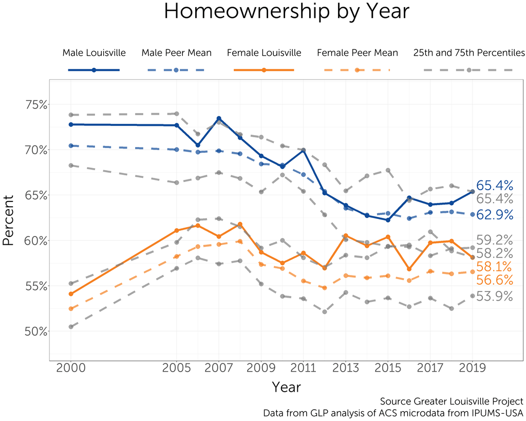

```r
#H_gen_trend<-survey_by_demog(census_microdata081122, weight_var = "HHWT", 'homeownership')

H_gen_trend %<>%
  filter(
    var_type == 'percent',
    race == 'total',
    sex != 'total')

trend(H_gen_trend,
      homeownership,
      plot_title = "Homeownership by Year",
      cat = 'sex',
      y_title = 'Percent',
      caption_text =
      "Source Greater Louisville Project
       Data from GLP analysis of ACS microdata from IPUMS-USA")
```

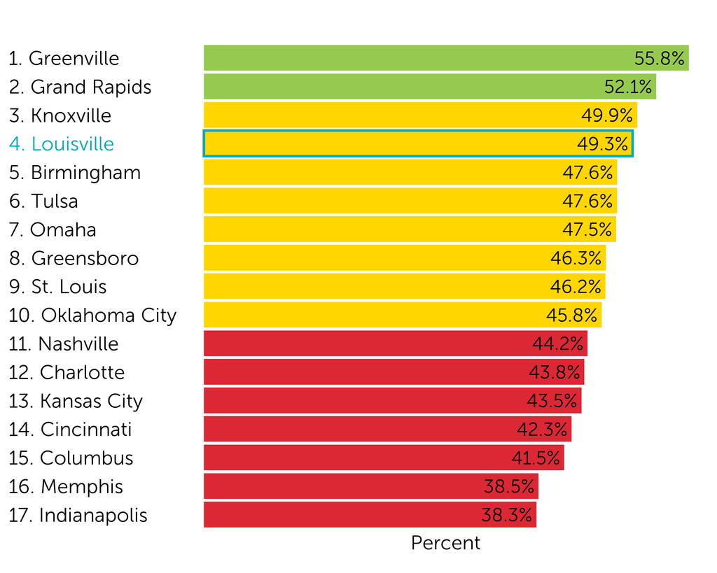

```r
# H_singFem_rank <- census_microdata081122 %>%
#   filter(
#     year == '2019',
#     earner_type == 'single_earner') %>%
#   survey_by_demog('homeownership', weight_var = "HHWT") %>%
#   filter(
#     sex == 'total',
#     race == 'total',
#     var_type == 'percent')

ranking(H_singFem_rank, 'homeownership')
```

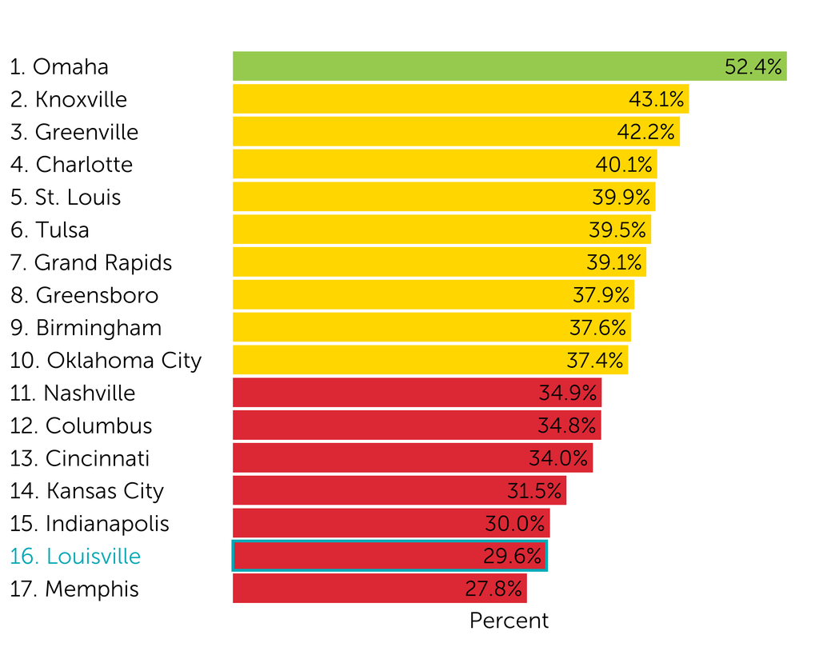

```r
# H_sinFem_kids <-census_microdata081122 %>%
#   filter(
#     year == '2019',
#     earner_type == 'single_earner',
#     NCHILD > 0) %>%
#   survey_by_demog('homeownership', weight_var = "HHWT") %>%
#   filter(
#     sex == 'total',
#     race == 'total',
#     var_type == 'percent')

ranking(H_sinFem_kids, 'homeownership')
```

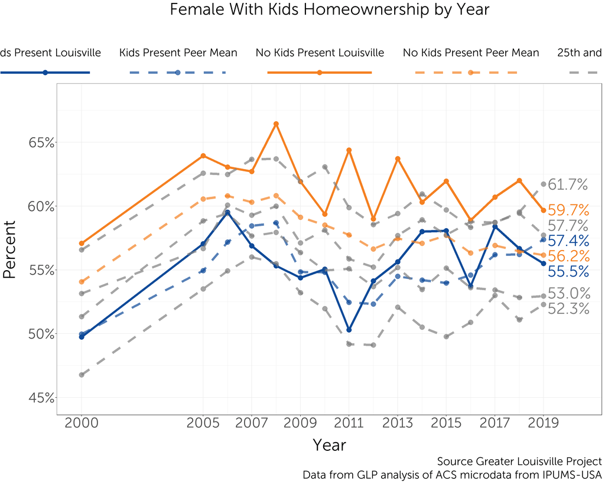

```r
# H_s_m_kids_trend <- survey_by_demog(census_microdata081122 ,weight_var = "HHWT", 'homeownership', other_grouping_vars = c("kd_pres"))

H_s_m_kids_trend %<>%
  filter(
    var_type == 'percent',
    race == 'total',
    sex == "female") %>%
  pivot_wider(names_from = 'kd_pres', values_from = 'homeownership') %>%
  select(-sex)

trend(H_s_m_kids_trend,
      kids:no_kids,
      plot_title = "Female With Kids Homeownership by Year",
      cat = c("Kids Present" = "kids", "No Kids Present" = "no_kids"),
      y_title = 'Percent',
      caption_text =
      "Source Greater Louisville Project
       Data from GLP analysis of ACS microdata from IPUMS-USA")
```

[figure not shown]

```r
# H_Fem_race <- survey_by_demog(census_microdata081122 ,weight_var = "HHWT", 'homeownership')

H_Fem_race %<>%
  filter(
    var_type == 'percent',
    race != 'total',
    sex == 'total')

trend(H_Fem_race,
      homeownership,
      plot_title = "Female With Kids Homeownership by Year",
      cat = 'race',
      y_title = 'Percent',
      caption_text =
      "Source Greater Louisville Project
       Data from GLP analysis of ACS microdata from IPUMS-USA")
```

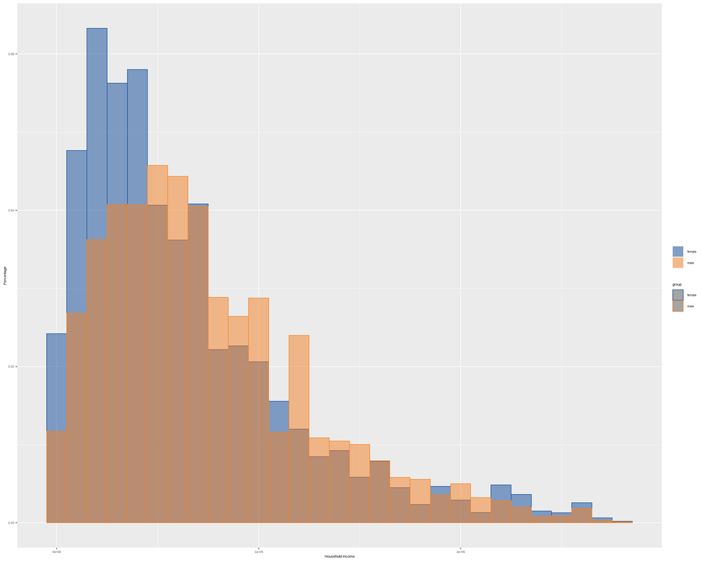

```r
#################KEEP################

## create hist for each of the most three recent years -> just for verification...that there isnt anything weird
## if feeling funky, use gganimate to create a gif of histograms from 2000 to 2019

#TO DO:
# facet this vertically
# Change the x-axis to a dollar format (see trendline function in trendline_helpers.R)
# Label the x-axis on every $50,000?
# Let's use counts on the y-axis for the male and female graph
# Format the y-axis with commas
# remove legend?

lville_2019 %>%
  filter(HHINCOME <= cut_95) %>%
        func_plt_hist_overlay( "sex")
```

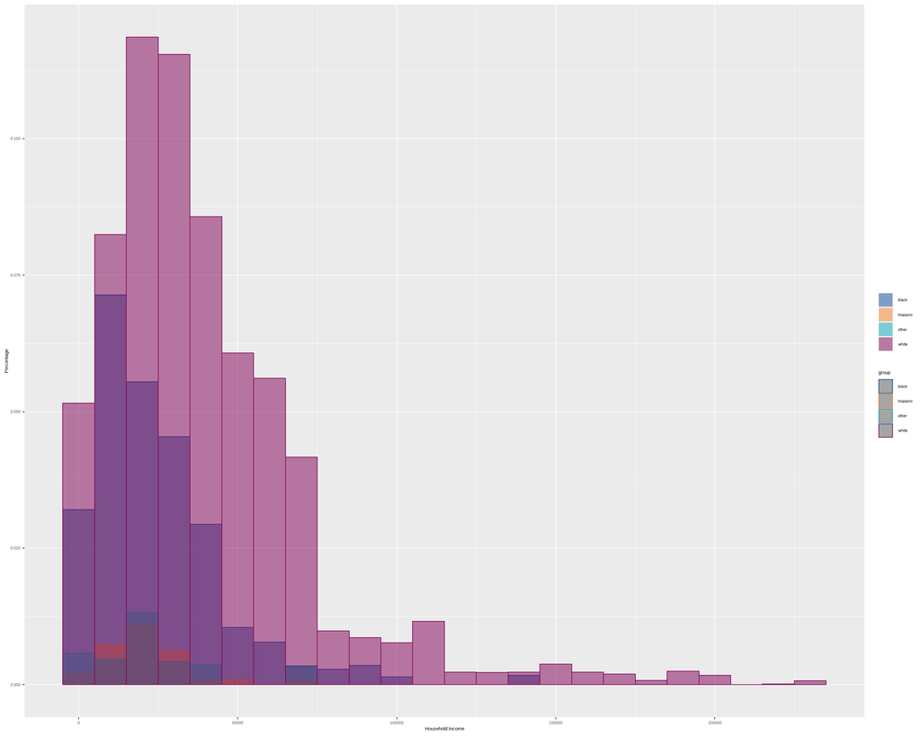

```r
# TO DO
# facet this into four panels
# Either check that the y-axis become independent to get more info around other groups OR change the data from counts to percentages


lville_2019 %>%
  filter(
    sex == 'female',
    earner_type == 'single_earner',
    HHINCOME <= cut_95) %>%
  func_plt_hist_overlay( "race")
```

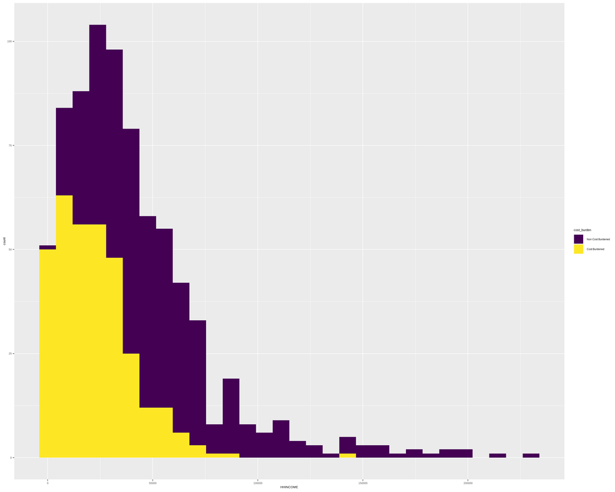

```r
# TO DO
# see above for x and y axis to-dos
# Drop the legend title (see )


cost_burden_sf <- lville_2019 %>%
  filter(
    sex == 'female',
    earner_type == 'single_earner',
    HHINCOME <= cut_95) %>%
  mutate(
    cost_burden = factor(cost_burden,
                         levels = rev(c(TRUE, FALSE)),
                         labels = rev(c("Cost Burdened", "Non Cost Burdened")),
                         ordered = TRUE))

ggplot(cost_burden_sf,
       aes(x = HHINCOME, fill = cost_burden),
       color="#00A9B7",
       alpha=0.5,
       position = "stack",
       binwidth = 10000) +
geom_histogram()
```

[figure not shown]

```r
# I_CB_earn_trend <- survey_by_demog(census_microdata081122, weight_var = "HHWT", 'cost_burden', other_grouping_vars = c('earner_type'), breakdowns = "sex")

I_CB_earn_trend %<>%
  filter(
    var_type == 'percent',
    race == 'total',
    sex == 'female') %>%
  select(-sex) %>%
  pivot_wider(names_from = "earner_type", values_from = "cost_burden")


trend(I_CB_earn_trend,
      multi_earner:single_earner,
      plot_title = "Homeownership by Year",
      cat = c("Multi Earner" = "multi_earner", "Single Earner" = "single_earner"),
      y_title = 'Percent',
      caption_text =
      "Source Greater Louisville Project
       Data from GLP analysis of ACS microdata from IPUMS-USA")
```

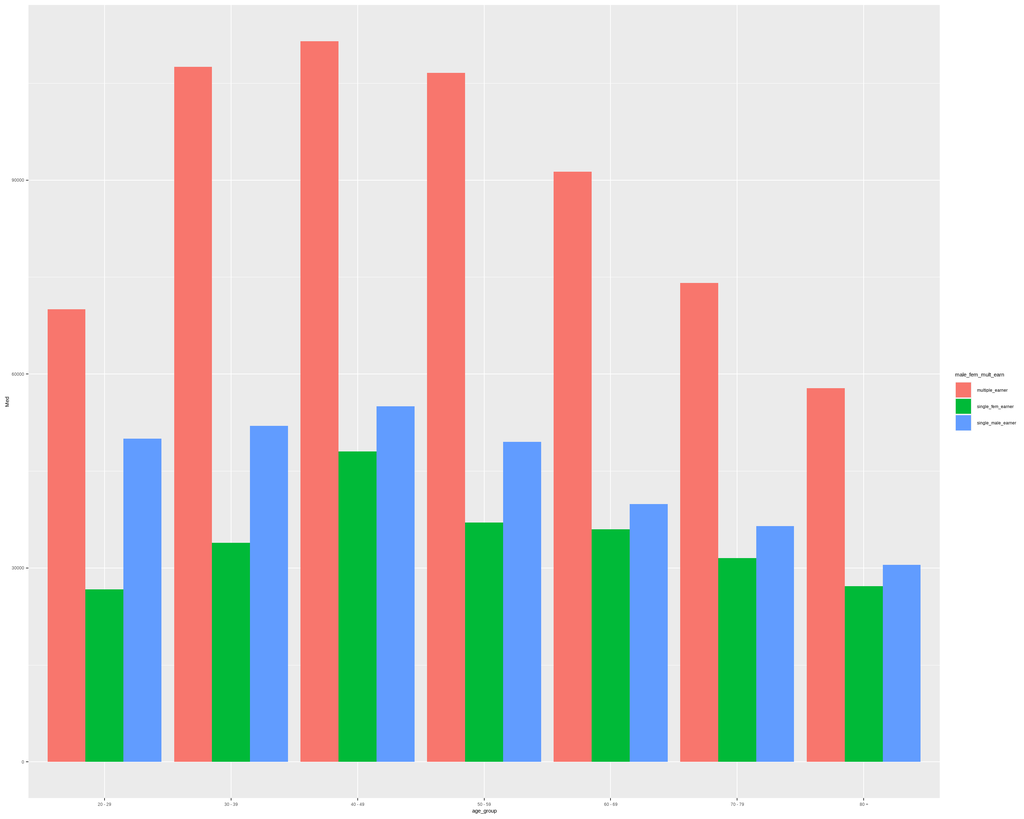

```r
I_median_earn_age <- lville_2019 %>%
  group_by(age_group, male_fem_mult_earn) %>%
  summarize(Med=median(HHINCOME))

ggplot(I_median_earn_age,
       aes(x=age_group, y=Med, fill = male_fem_mult_earn)) +
  geom_bar(stat="identity", position='dodge')
```

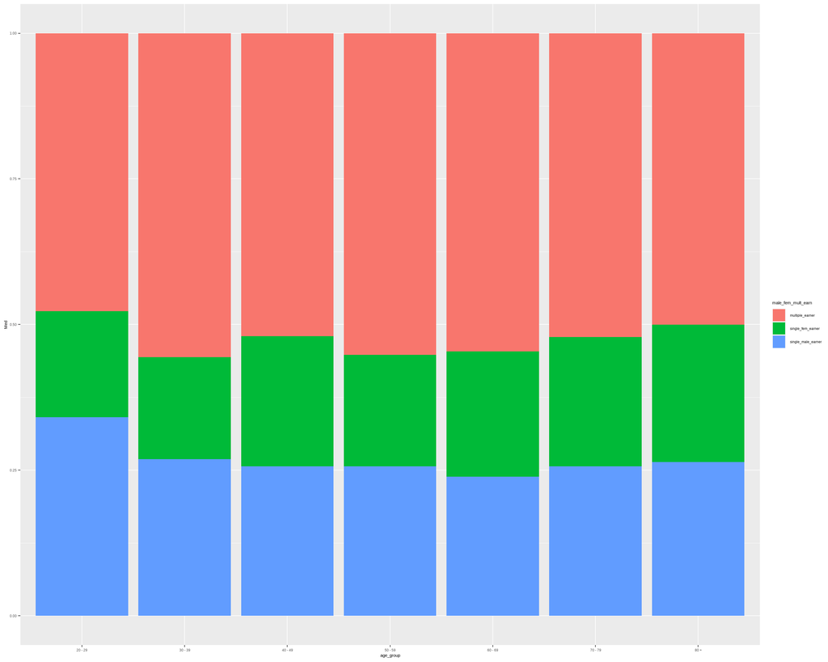

```r
#Do not use
ggplot(I_median_earn_age,
       aes(x=age_group, y=Med, fill = male_fem_mult_earn)) +
  geom_bar(stat="identity", position='fill')
```

# Education

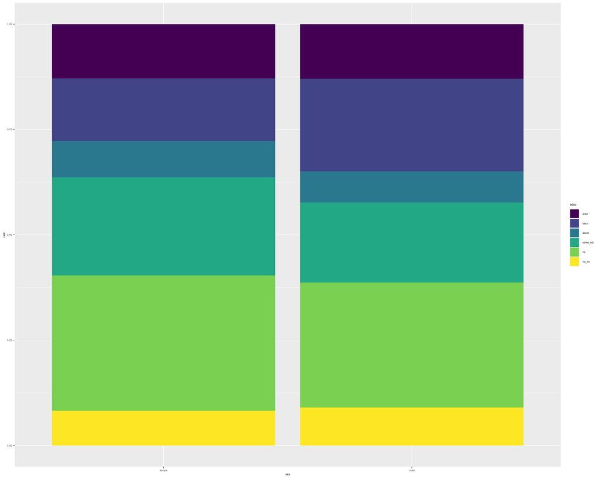

```r
E_singM_singF <- lville_2019 %>%
  filter(earner_type == 'single_earner') %>%
  group_by(sex, educ) %>%
  summarize(n=sum(HHWT, na.rm = TRUE)) %>%
  mutate(
    total = sum(n),
    rate = n/sum(n)*100,
    educ = factor(educ,
                  levels = rev(c("no_hs", "hs", "some_col", "assoc", "bach","grad")),
                  ordered = TRUE))

ggplot(E_singM_singF,
       aes(x=sex, y=rate, fill=educ)) +
  geom_bar(stat="identity", position='fill')
```

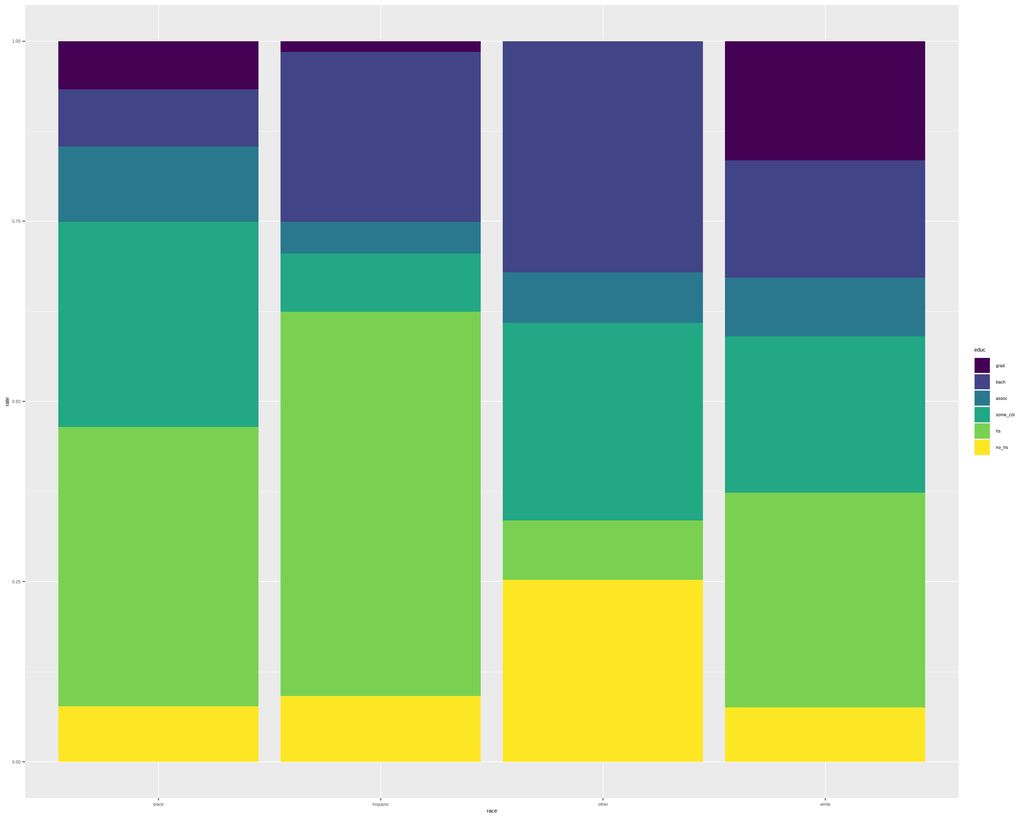

```r
E_singF_race <- lville_2019 %>%
  filter(
    sex == 'female',
    earner_type == 'single_earner') %>%
  group_by(race, educ) %>%
  summarize(n=sum(HHWT, na.rm = TRUE)) %>%
  mutate(
    total = sum(n),
    rate = n/sum(n)*100,
    educ = factor(educ,
                  levels = rev(c("no_hs", "hs", "some_col", "assoc", "bach","grad")),
                  ordered = TRUE))

ggplot(E_singF_race, aes(x=race, y=rate, fill=educ)) +
geom_bar(stat="identity", position='fill')
```

# Household Age

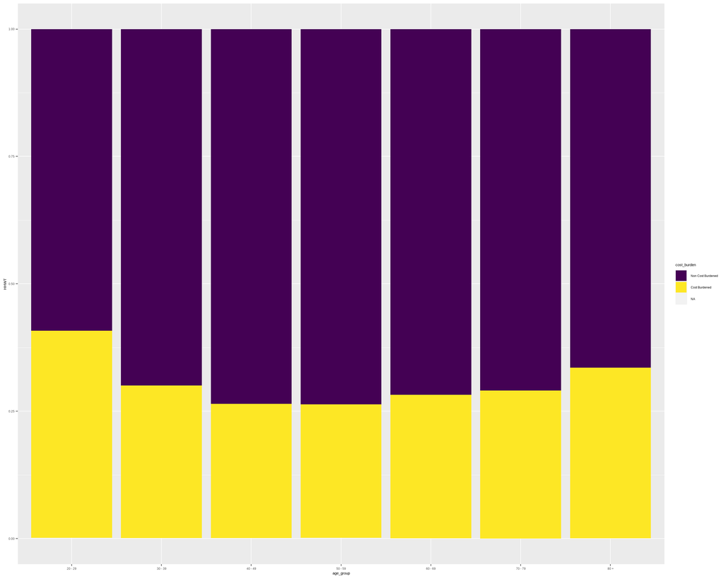

```r
#Stacked histogram

cost_burden_age_sf <- census_microdata081122 %>%
    filter(year %in% 2010:2019) %>%
  mutate(
    cost_burden = factor(cost_burden,
                         levels = rev(c(TRUE, FALSE)),
                         labels = rev(c("Cost Burdened", "Non Cost Burdened")),
                         ordered = TRUE)
    )


ggplot(cost_burden_age_sf,
       aes(x=age_group, y=HHWT , fill=cost_burden),
        color="#00A9B7") +
geom_bar(stat="identity", position='fill')
```

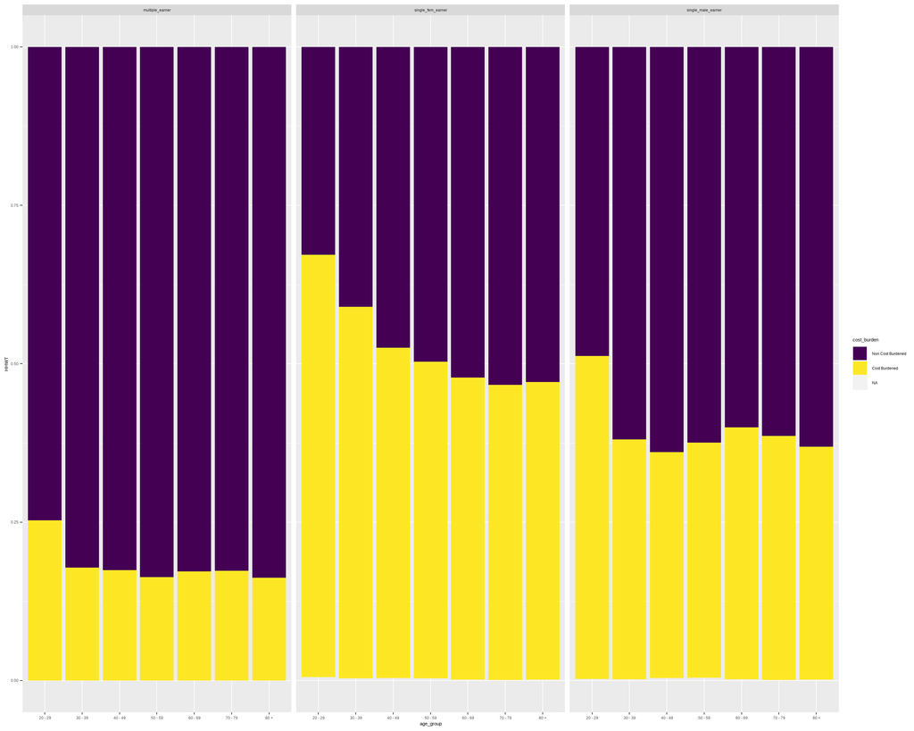

```r
ggplot(cost_burden_age_sf,
       aes(x=age_group, y=HHWT , fill=cost_burden),
        color="#00A9B7") +
geom_bar(stat="identity", position='fill')+
facet_wrap(~male_fem_mult_earn)
```

# Earner Types Over Time

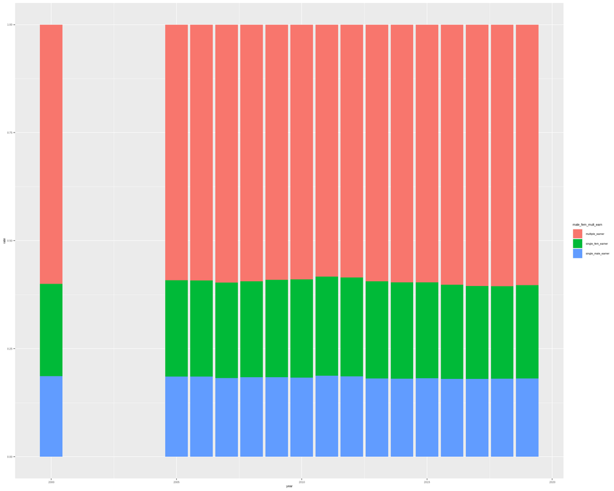

```r
earner_trend <- census_microdata081122 %>%

  mutate(
    male_fem_mult_earn = case_when(
      sex == 'female' & earner_type == 'single_earner' ~ 'single_fem_earner',
      sex == 'male' & earner_type == 'single_earner' ~ 'single_male_earner',
      earner_type == 'multi_earner' ~ 'multiple_earner')
  ) %>%
  group_by(year, male_fem_mult_earn) %>%
  summarize(n=sum(HHWT, na.rm = TRUE)) %>%
  mutate(
    total = sum(n),
    rate = n/sum(n)*100)

ggplot(earner_trend,
       aes(x=year, y=rate, fill=male_fem_mult_earn),
        color="#00A9B7") +
geom_bar(stat="identity", position='fill')
```